# Analysis on Veg1.xslx

## Team members

### Group 6

- Francesco Ignazio Re
- YinChia Huang
- Yue Wu

## Outline

- Introduction
- Data Cleaning
- Data Visualization and Exploration
- Chemicals Toxicity information
- Conclusion

## Introduction

The aim of this analysis is to give a clear understanding of the data-set veg1.xlsx. In order to do that, we intend to make the data set more intuitive to read and work on.

### What's the data set about?

-The data set gathers information on the amount and type of chemicals found in food crops between the years 1990/2016 (not all the years are present), showing the location of the observations and the kind of measurement carried out.

We would like to get a deeper insight in order to understand if the use of these chemicals inpacts significantly the quality of the crops and the land they were grown in.

## Data Cleaning

The first thing to do is to better organize the information that we have. We make sure that every variable has a column of its own. Below, some examples:

```
#Separating the column Category into Labe and Quant

ex1 <- separate(veg.3,Category,into = c("Label", "Quant"), sep=",")

#Separating the colum Quant into Type and Name

ex2 <- separate(ex1, Quant, into=c("Type","Name"), sep = ":")

#Separating chemicals name from their IDs, and deleting brackets

ex8 <- ex7.1 %>% separate(Name, into = c("Name", "ID"), sep = "=")%>%
  separate(Name, into = c("Delete", "Name"), sep = "[()]") %>%
  separate(ID, into = c("ID", "Delete1"), sep = "[)]") %>%
  select(-Delete, -Delete1)
```

## Data Cleaning

A tricky step was understanding that many observations where just statistical results of a previous analysis. We selected them and separeted their values from the ones of the real observations. Finally, we replace the values that lack any useful information with NAs.

```
#We discern the observation that are statistical results.
ex6 <- ex5 %>%
  separate(Measurement,
  into = c("Measurement", "Info on Measurement", "Stats"),
  sep = ",")

#Finally, let's replace the values such as (D),(Z) and (NA)
#with NA and separate actual values from statistical results

ex9 <- ex8%>% filter(!Value %in% c("(D)", "(Z)", "(NA)", NA))%>%
  filter(!Name %in% c("TOTAL")) %>%
  filter(Stats %in% NA) %>%
  select(-Stats)
```

## Data Visualization and Exploration

After tidying our dataset, we are able to start visualizing the information we got, focusing on our area of interest: the amount of restricted chemicals found in the crops.

It turns out that Broccoli and Cauliflowers and the only vegetables of the data set presenting restricted chemicals.

## Restricted Chemicals in Broccoli

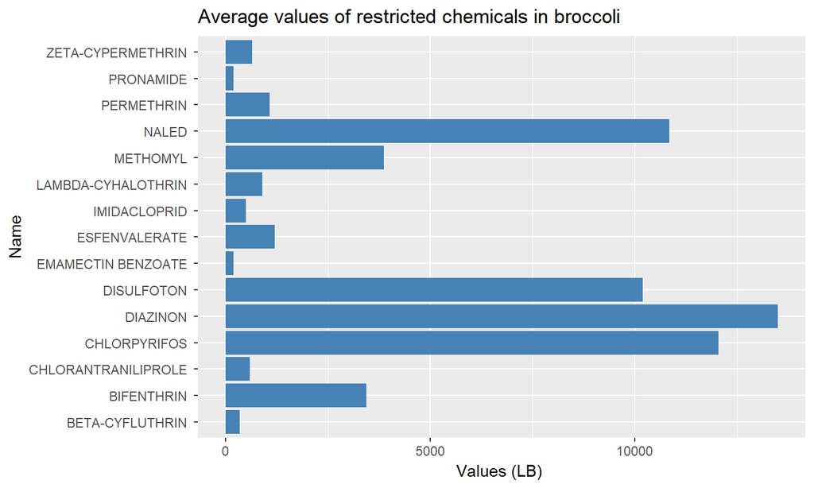

## Restricted Chemicals in Cauliflowers

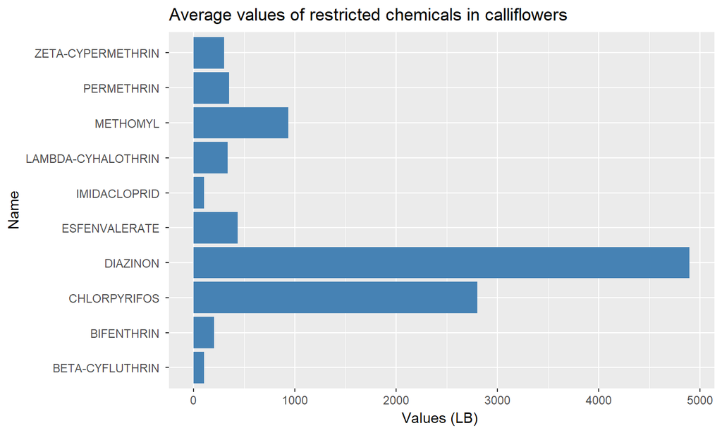

## Values of restricted chemicals in Broccoli by year

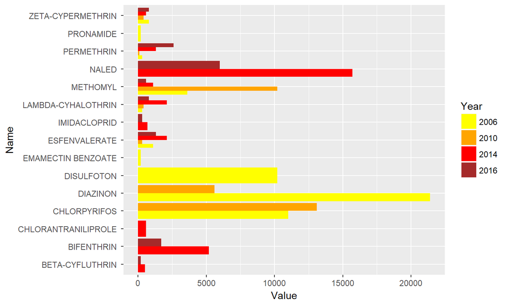

## Values of restricted chemicals in Cauliflowers by year

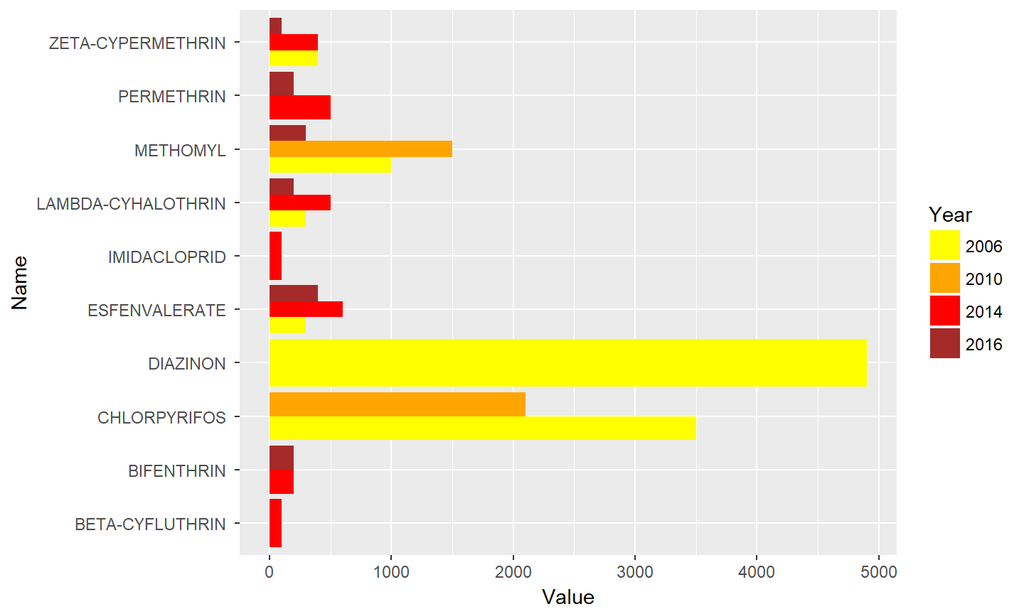

## Total Average Between Broccoli and Cauliflowers

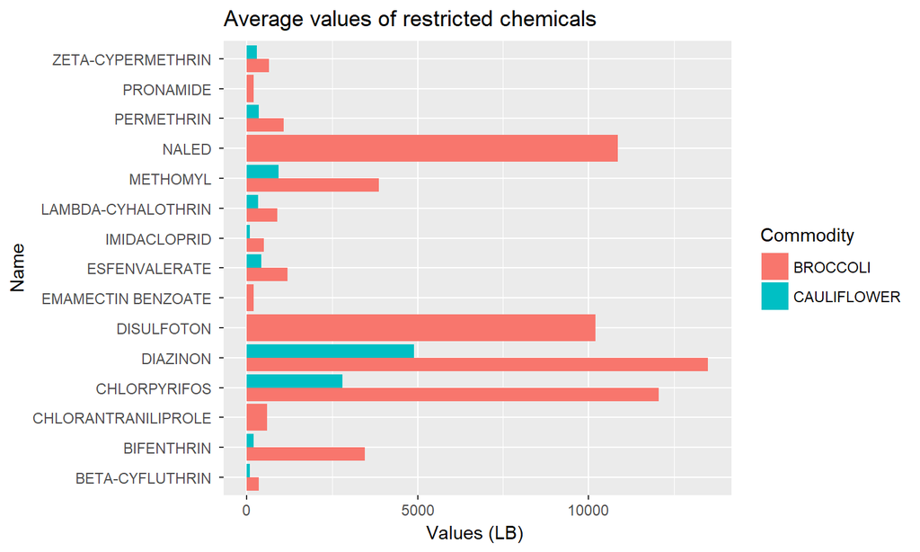

## Chemicals toxicity information

Now that we have a general understanding of the quantity of each chemicals in the vegetables, we would like to know more about the chemical properties. For this reason, we gathered information on every chemical and created a table displaying:

-Soil Adsorption Coefficient: measures the amount of chemical substance adsorbed onto soil per amount of water. If the values are very low, then the soil doesn't adsorb the chemical properly and there's high risk of ground water contamination.

-LD50 on rats: value of chemical necessary to cause mortality in rats. (In the study the chemical is administered orally)

-LC50 on earthworms: concentration of chemical in air in order to cause mortality in earthworms.

## Toxicity table

Here the first rows of the table:

| Name | Units | Priority | Values.for.LC50.on.earthworms | Values.for.LD50.on.rats | ID |
| --- | --- | --- | --- | --- | --- |
| BIFENTHRIN | mg/kg | 6 | NA | 54.5000 | 128825 |
| CHLORANTRANILIPROLE | mg/kg | 6 | NA | 5000.0000 | 90100 |
| CHLORPYRIFOS | mg/kg | 6 | 375.84 | 202.2500 | 59101 |
| DIAZINON | mg/kg | 6 | NA | 480.0526 | 57801 |
| DISULFOTON | mg/kg | 6 | NA | 5.1400 | 32501 |
| EMAMECTIN BENZOATE | mg/kg | 6 | 185.75 | NA | 122806 |

## Analysis on toxicity by chemical in rats

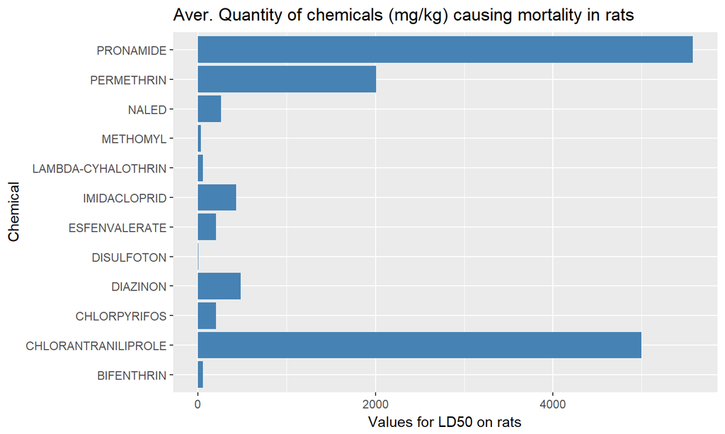

## Analysis on toxicity by chemical in earthworms

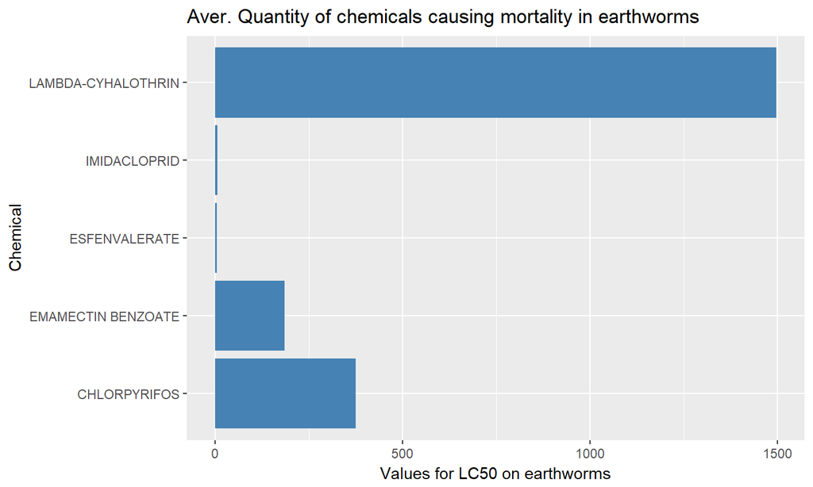

## Joining toxicity info to the overall table

(first 9 column)

| Year | Geo | State | Region | Commodity | Info.on.Commodity | Measurement | Info.on.Measurement | Units |
| --- | --- | --- | --- | --- | --- | --- | --- | --- |
| 2014 | MULTI-STATE | NA | PROGRAM STATES | BROCCOLI | BROCCOLI | APPLICATIONS | MEASURED IN LB | mg/kg |
| 2010 | MULTI-STATE | NA | PROGRAM STATES | BROCCOLI | BROCCOLI | APPLICATIONS | MEASURED IN LB | mg/kg |
| 2010 | MULTI-STATE | NA | PROGRAM STATES | CAULIFLOWER | CAULIFLOWER | APPLICATIONS | MEASURED IN LB | mg/kg |
| 2006 | MULTI-STATE | NA | PROGRAM STATES | BROCCOLI | BROCCOLI | APPLICATIONS | MEASURED IN LB | mg/kg |
| 2006 | MULTI-STATE | NA | PROGRAM STATES | CAULIFLOWER | CAULIFLOWER | APPLICATIONS | MEASURED IN LB | mg/kg |

## Joining toxicity info to the overall table

(last 8 column)

| Label | Name | Type | Value | Priority | LC50 on earthworms | LD50 on rats | Soil Adsorption Coeff |
| --- | --- | --- | --- | --- | --- | --- | --- |
| RESTRICTED USE CHEMICAL | CHLORANTRANILIPROLE | INSECTICIDE | 600 | 6 | NA | 5000.00 | 839 |
| RESTRICTED USE CHEMICAL | CHLORPYRIFOS | INSECTICIDE | 13100 | 6 | 375.84 | 202.25 | 5010 |
| RESTRICTED USE CHEMICAL | CHLORPYRIFOS | INSECTICIDE | 2100 | 6 | 375.84 | 202.25 | 5010 |
| RESTRICTED USE CHEMICAL | CHLORPYRIFOS | INSECTICIDE | 11000 | 6 | 375.84 | 202.25 | 5010 |
| RESTRICTED USE CHEMICAL | CHLORPYRIFOS | INSECTICIDE | 3500 | 6 | 375.84 | 202.25 | 5010 |